# R: Exploration of data with Visualization

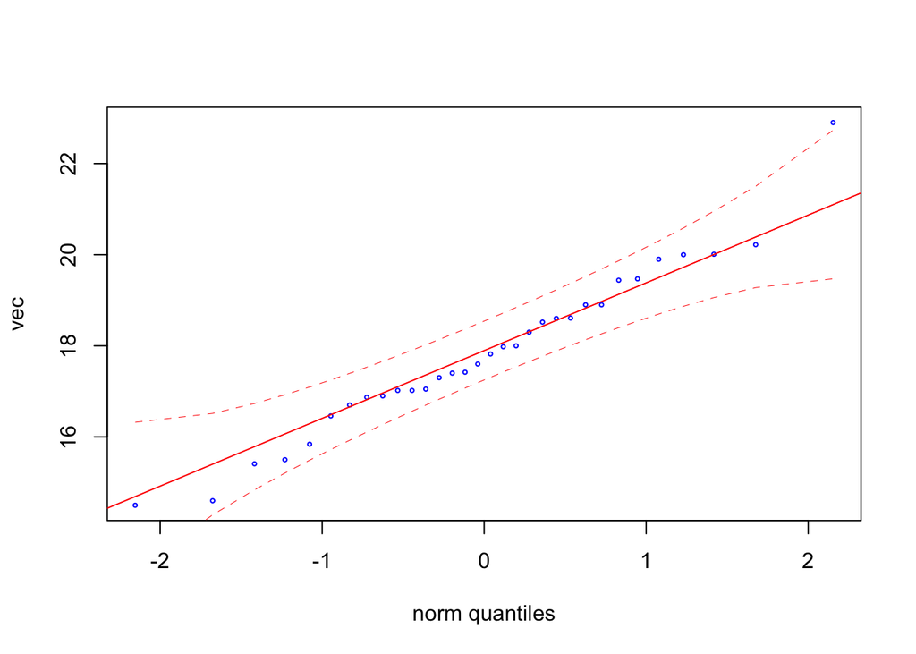

```r
qqfun(vec, distribution="norm")
```

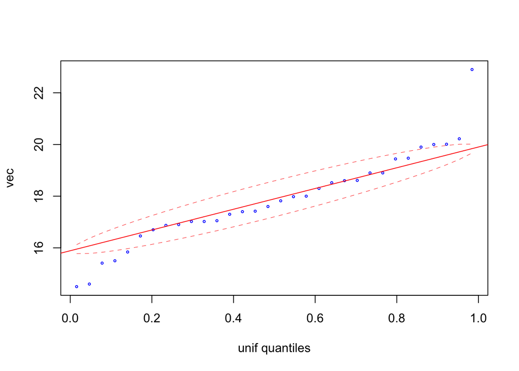

```r
qqfun(vec, distribution="unif")
```

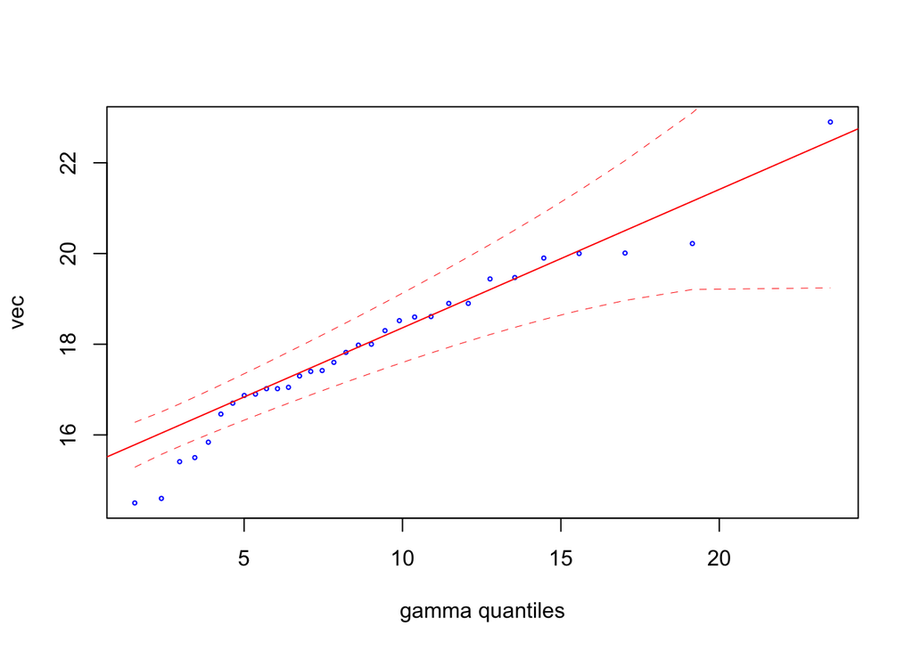

```r
qqfun(vec, distribution="gamma", shape=3, scale=3)
```

It seems from the abobe plots that the Normal distribution is a good fit.

We want to test if the underlying normal distribution it is mapped to has mean 0 or not.

```r
t.test(vec)
```

```
##
##  One Sample t-test
##
## data:  vec
## t = 56.503, df = 31, p-value < 2.2e-16
## alternative hypothesis: true mean is not equal to 0
## 95 percent confidence interval:
##  17.20449 18.49301
## sample estimates:
## mean of x
##  17.84875
```

The p-value is again a measure of whether the hypothesis is true or not. Since it is less than 0.05, we say it does not have mean 0. Is it obvious?

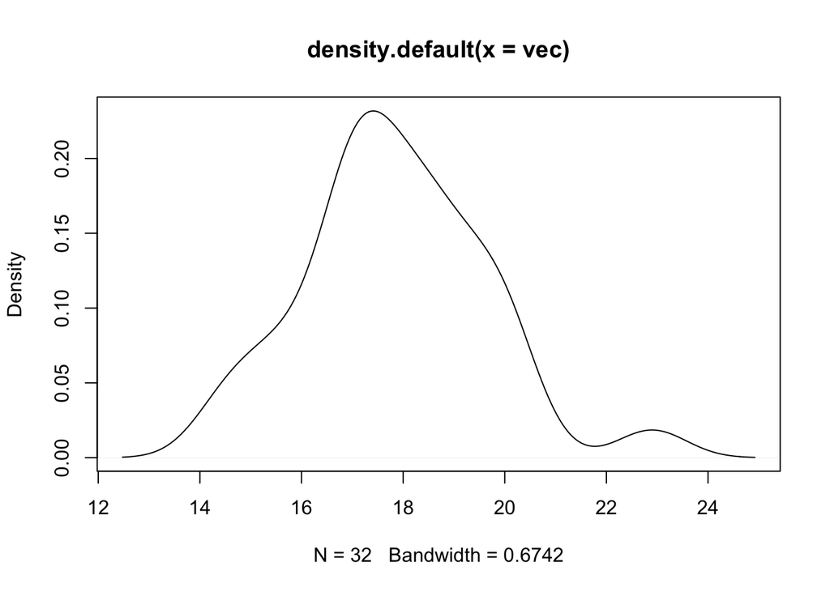

```r
plot(density(vec))
```

We can standardize vec by subtracting the mean and then dividing by standard deviation. That is called *z/t-score*.

```r
z_vec <- (vec - mean(vec))/sd(vec)
```

Lets now use t-test on this vector. This should satisfy the Normal distribution with mean 0 assumption.

```r
t.test(z_vec)
```

```
##
##  One Sample t-test
##
## data:  z_vec
## t = 2.9979e-15, df = 31, p-value = 1
## alternative hypothesis: true mean is not equal to 0
## 95 percent confidence interval:
##  -0.3605384  0.3605384
## sample estimates:
##   mean of x
## 5.29958e-16
```

Notice the very high p-value.